# Module 10: Categorical Predictors

Author

Affiliation

Adam Spiegler

University of Colorado Denver

## Additional Reading

- [Section 3.8 Categorical Predictors](https://jfrench.github.io/LinearRegression/linear-model-estimation.html#categorical-predictors) from *A Progressive Introduction to Linear Models*
- Chapter 7 of *Linear Regression Models: Applications in R* ([link to library ebook](https://go.exlibris.link/Q7wgCRrz))
- Sections 5.1-5.2 of *Applied Linear Regression* ([link to library ebook](https://go.exlibris.link/69jsQwWW))

# Loading Required Packages

```r
library(tidyverse)
library(alr4) # to access UN11 data set
```

# Categorical Predictors

Categorical predictors are often called **factors**. Factors can have two levels (e.g., survived or died) or multiple levels (single, married, divorced, widowed).

We will discuss two basic uses of categorical predictors in linear regression models.

- **Parallel lines regression models** produce different parallel lines for each level of the categorical variable.
- **Separate lines regression models** produce separate (typically non-parallel) lines for each level of the categorical variable.

## Nominal and Ordinal Variables

Categorical variables are often distinguished by whether or not they have a logical order or ranking:

- Those that cannot be ordered logically are called **nominal**. For example, gender, marital status, political party.
- Those that have an order in a sensible manner are called **ordinal**. For example, category of hurricane, high school class (freshman, sophomore, junior, senior).

# The United Nations Data

## Question 1

Run the code chunk below to load the `UN11` data set below and read the help documentation to familiarize yourself with the data. How many observations are in the data set? How many variables?

```r
data(UN11)
```

## Solution to Question 1

## Question 2

Create side-by-side box plots for the variable `lifeExpF` for each of the categories of the `group` variable and describe any interesting observations about the data.

### Solution to Question 2

# Indicator Variables

Suppose we wish to determine whether the categorical predictor marital status (single, cohabiting, married, divorced, and widowed) is associated with personal income. How is this type of descriptive variable entered into a quantitative model?

**Dummy** or **indicator variables** are used to include categorical predictors in a regression model.

- An **indicator function** is a function that takes the value 1 if a certain property is true and 0 otherwise.
- An **indicator variable** is the variable that results from applying an indicator function to each observation of a variable.

We denote indicator functions using the notation,

$$I_S(x) =
\begin{cases}
1 & \textrm{if}\;x \in S\\
0 & \textrm{if}\;x \notin S
\end{cases}.$$

Some examples of indicator functions:

- $I_{\rm{africa}}(\text{"Afghanistan"})= 0$
- $I_{\rm{africa}}(\text{"Botswana"})= 1$
- $I_{\{2,3\}}(2) = 1$.
- $I_{\{2,3\}}(2.5) = 0$.

In our example, `group` has $d=3$ levels, $L_1$, $L_2$, and $L_3$ corresponding to `oecd`, `other`, and `africa`, respectively. We can define three different dummy variables:

- $D_1$ (is country OECD?),
- $D_2$ (is country Other?), and
- $D_3$ (is country in Africa?).

Let $c_i$ denote the value of $C$ for observation $i$. For example $c_2 = \text{"other"}$. We assign values to $D_1$, $D_2$, and $D_3$ using the indicator function below.

$$d_{i,j} = I_{L_j}(c_i) = \left\{ \begin{array}{ll} 1 & \mbox{if } c_i \in L_j \\
0 & \mbox{if } c_i \notin L_j \end{array} \right.$$

**Note**

- Values $-1$ and $1$, or $1$ and $2$, are sometimes used, but this is less common and more difficult to interpret.
- The assignment labels are mostly arbitrary and do not affect the results.

## Question 3

Use the `if_else()` function to create and assign values to dummy variables `d1`, `d2`, and `d3`. Replace `??` in the code chunk below with appropriate expressions/values. Then run the code and check the output displayed on screen.

### Solution to Question 3

```r
UN11 |>
  mutate(d1 = if_else(??),
         d2 = if_else(??),
         d3 = if_else(??)) |>
  select(c(group, d1, d2, d3))
```

# One-Factor Models

If the only predictor is a factor, then the regression model is called a **one-factor** or **one-way** design. Regression coefficients for factor variables in a one-way model are often called **effects**.

## Question 4

Let $Y$ denote the response variable `lifeExpF`. What would be problematic about using the linear model proposed below?

$$Y = \beta_0 + \beta_1 D_1 + \beta_2 D_2 + \beta_3 D_3 + \epsilon$$

### Solution to Question 4

## Question 5

Using a treatment contrast with the first level of group as the reference level (`oecd`), what would be our model for `oecd` countries? What is the model for `other` countries? For `africa` countries?

$$E(\mbox{lifeExpF } \vert \mbox{ group})= \beta_0+ \beta_2 D_2+ \beta_3 D_3$$
.

### Solution to Question 5

## Fitting a One-Factor Model with R

R will fit a one-factor model if you:

- Add the necessary dummy variables manually to the `formula` argument of `lm`.
- Include the factor variable in the formula of `lm` (dropping the dummy variable for the first level of the factor automatically).

```r
# First we add dummy variables to the data frame
UN11$d1 <- if_else(UN11$group == "oecd", 1, 0)
UN11$d2 <- if_else(UN11$group == "other", 1, 0)
UN11$d3 <- if_else(UN11$group == "africa", 1, 0)
```

```r
# fit overparameterized model
lm(lifeExpF ~ d1 + d2 + d3, data = UN11)
```

```
Call:
lm(formula = lifeExpF ~ d1 + d2 + d3, data = UN11)

Coefficients:
(Intercept)           d1           d2           d3
      59.77        22.67        15.55           NA
```

```r
# fit proper model
lm(lifeExpF ~ d2 + d3, data = UN11)
```

```
Call:
lm(formula = lifeExpF ~ d2 + d3, data = UN11)

Coefficients:
(Intercept)           d2           d3
      82.45        -7.12       -22.67
```

```r
# What R will do by default
lm(lifeExpF ~ group, data = UN11)
```

```
Call:
lm(formula = lifeExpF ~ group, data = UN11)

Coefficients:
(Intercept)   groupother  groupafrica
      82.45        -7.12       -22.67
```

## Question 6

Compare the output from the previous three models and comment on the differences, similarities of each.

### Solution to Question 6

## Question 7

Interpret the practical meaning of the regression coefficients $\widehat{\beta}_0$, $\widehat{\beta}_2$ and $\widehat{\beta}_3$

### Solution to Question 7

# Factors and Quantitative Predictors

It is common to study the effect of a factor after adjusting for one or more other quantitative regressors. If we have a mixture of factors and quantitative variables in our data, it’s useful to create a scatter plot of the response versus the quantitative predictor that distinguishes the observations for each level of the categorical predictor. - This helps us assess whether the relationship between the response and quantitative regressor differs for the levels of the factor.

## Question 8

Create a plot to show the relation of the response `lifeExpF` and predictor `log(ppgdp)` for each of the three country `groups`. What are some interesting observations/patterns you can observe in the plots?

### Solution to Question 8

# Comparing Models

Suppose we have a response $Y$, a quantitative regressor $X$, and a *two-level factor* variable represented by a single dummy variable $D$:

**Note**

The model described extends naturally when the factor has more than 2 levels (as with our `group` predictor).

$$D = \left\{ \begin{array}{ll}
0 & \mbox{for the reference level} \\
1 & \mbox{for the treatment level} \end{array} \right.$$

Consider several possible regression models.

## A Simple Linear Regression Model

A **simple linear regression model** with one quantitative predictor will produce the same, single regression line for all levels of the categorical variable (combined), $Y= \beta_0 + \beta_1 X + \epsilon$.

## Question 9

Enter code to fit a simple linear model with `log(ppgdp)` as the regressor and `lifeExpF` as the response. Store the output of the linear model to an object called `lmods` (`s` is for simple). Add this line to the scatter plot you created in Question 8

### Solution to Question 9

## A One-Way Model

```r
lmodo <- lm(lifeExpF ~  group, data = UN11)
summary(lmodo)
```

```
Call:
lm(formula = lifeExpF ~ group, data = UN11)

Residuals:
     Min       1Q   Median       3Q      Max
-25.8367  -3.3045   0.3635   2.7183  18.2277

Coefficients:
            Estimate Std. Error t value Pr(>|t|)
(Intercept)   82.446      1.128  73.095  < 2e-16 ***
groupother    -7.120      1.271  -5.602  7.1e-08 ***
groupafrica  -22.674      1.420 -15.968  < 2e-16 ***
---
Signif. codes:  0 '***' 0.001 '**' 0.01 '*' 0.05 '.' 0.1 ' ' 1

Residual standard error: 6.28 on 196 degrees of freedom
Multiple R-squared:  0.6191,    Adjusted R-squared:  0.6152
F-statistic: 159.3 on 2 and 196 DF,  p-value: < 2.2e-16
```

$$\begin{align}
& \widehat{E} (\mbox{lifeExpF }\vert\mbox{ group = oecd}) = \widehat{\beta}_0 = 82.45\\
& \widehat{E} (\mbox{lifeExpF } \vert\mbox{ group = other}) = \widehat{\beta}_0 + \widehat{\beta}_2 = 82.45 - 7.12 = 75.33 \\
& \widehat{E} (\mbox{lifeExpF } \vert \mbox{ group = africa})= \widehat{\beta}_0 + \widehat{\beta}_3 = 82.45 - 22.67 = 59.79.
\end{align}$$

## Main Effects or Parallel Lines Model

**Main effects or parallel lines models** create separate regression lines for each group, each having the same slope, $Y= \beta_0+ \beta_1 X+ \beta_2 D + \epsilon$.

- $\beta_2$ represents the vertical distance between the regression lines (the effect of the treatment).

## Question 10

Enter code to fit a main effects model with `log(ppgdp)` as a predictor with `d2` and `d3` as the treatment levels and `lifeExpF` as the response. Store the result to `lmodp`. Then interpret the values of the coefficients in practical terms.

### Solution to Question 10

## Question 11

Find formulas for each of the parallel lines in your model from Question 10.

### Solution to Question 11

### Plotting Parallel Lines Model

```r
# create column of predictions
UN11 <- UN11 |>
  mutate(life_fitted = predict(lmodp))
```

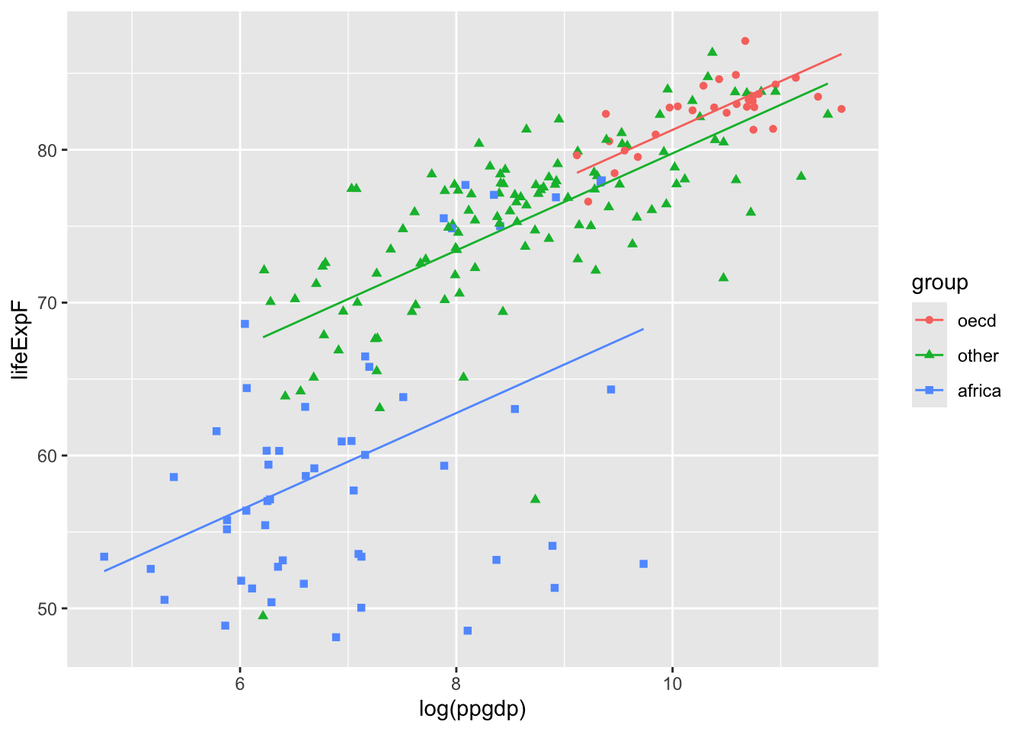

```r
# add a line geom for each model
ggplot(UN11, aes(x = log(ppgdp), y = lifeExpF)) +
  geom_point(aes(shape = group, color = group)) +
  geom_line(aes(x = log(ppgdp), y = life_fitted, color = group))
```

## Interaction Model

**Interaction or separate lines model** plot separate lines for each group that have different slopes, $Y= \beta_0+ \beta_1 X+ \beta_2 D+ \beta_3 XD + \epsilon$.

In R, we can use the syntax `y ~ x + u + x:u` or `y ~ x*u`

- `x:d` means the interaction between `x` and `d`.
- `x*d` means the cross between `x` and `d` (`x`, `d`, and the interaction between `x` and `d`).

## Question 12

Enter code to fit an interaction model with `log(ppgdp)` as a predictor with `d2` and `d3` (dummy variables for `group`) as the treatment levels and `lifeExpF` as the response. Store the result to `lmodi`.

### Solution to Question 12

## Question 13

Find formulas for each of the separate lines in your model from Question 12

### Solution to Question 13

## Plotting the Interaction Model

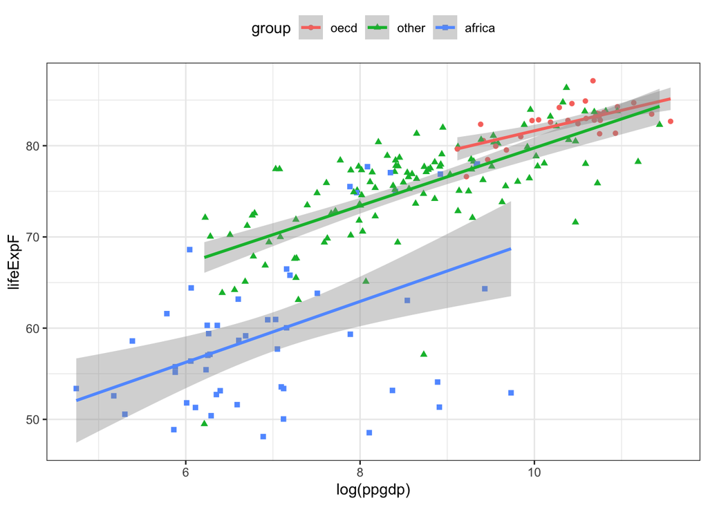

```r
# using ggplot2
ggplot(UN11, aes(x = log(ppgdp), y = lifeExpF, col = group, shape = group)) +
  geom_point() +
  geom_smooth(method = "lm") +
  theme_bw() +
  theme(legend.position="top")
```

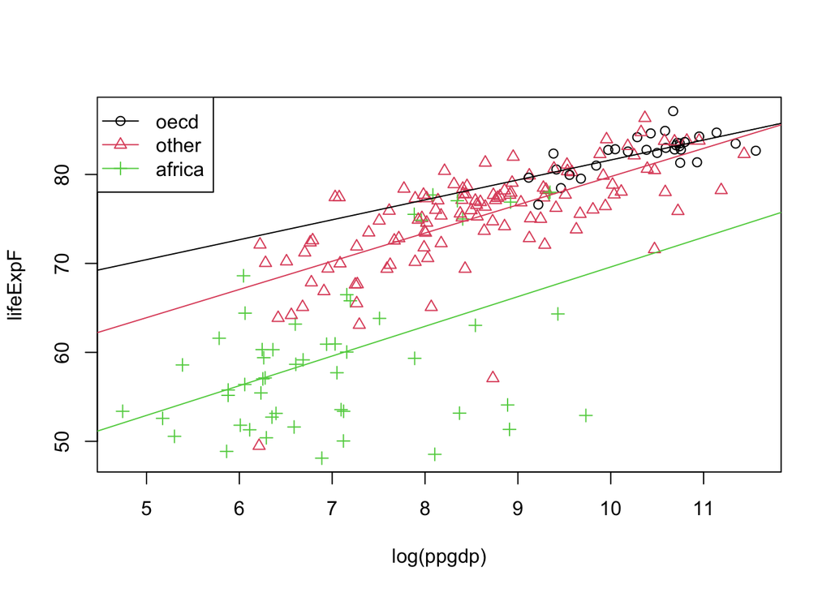

```r
# using base graphics
# create different colors/symbols for each group
grp_col = as.numeric(UN11$group)

# plot data, using different colors/symbols for each group
plot(lifeExpF ~ log(ppgdp), data = UN11,
     col = grp_col, pch = grp_col)
# fitted lines for each group,
# changing color for each group.
# Make sure to match the color number with color number used in plot!
abline(59.21366, 2.24254, col = 1)
abline(59.21366 - 11.17310, 2.24254 + 0.92944, col = 2)
abline(59.21366 - 22.98484, 2.24254 + 1.09498, col = 3)

# create the legend
legend("topleft", legend = c("oecd", "other", "africa"), col = 1:3, pch = 1:3, lty = 1)
```

## Question 14

Run the code cell below to display the first 10 rows of the model matrix for the interaction model. Based on the output, describe how are the last two columns of the model matrix $X$ computed?

```r
head(model.matrix(lmodi), 10)
```

### Solution to Question 14

## Question 15

Interpret each coefficient in your separate lines models from Question 13.

### Solution to Question 15

# Practice

Run the code cell below to load the `storms` data frame from the `dplyr` package. Then answer the questions below. Then run the second code cell below to store cleaned data to `storms_clean`.

```r
# load storms data
data(storms, package = "dplyr")
```

```r
# clean storms data
storms_clean <- storms |>
  select(c(wind, pressure, status, lat, long)) |>
  mutate(status = factor(status))
summary(storms_clean)
```

```
      wind           pressure                      status          lat
 Min.   : 10.00   Min.   : 882.0   tropical storm     :6830   Min.   : 7.00
 1st Qu.: 30.00   1st Qu.: 986.0   hurricane          :4803   1st Qu.:18.30
 Median : 45.00   Median :1000.0   tropical depression:3569   Median :26.60
 Mean   : 50.05   Mean   : 993.5   extratropical      :2151   Mean   :27.01
 3rd Qu.: 65.00   3rd Qu.:1007.0   other low          :1453   3rd Qu.:33.80
 Max.   :165.00   Max.   :1024.0   subtropical storm  : 298   Max.   :70.70
                                   (Other)            : 433
      long
 Min.   :-136.90
 1st Qu.: -78.80
 Median : -62.30
 Mean   : -61.56
 3rd Qu.: -45.50
 Max.   :  13.50
```

## Question 16

Create the following three plots. Plot the response `wind` on the $y$-axis and create

- One plot with `pressure` as the predictor on the $x$-axis.
- Another plot with `lat` as the predictor on the $x$-axis.
- A third plot with `long` as the predictor on the $x$-axis.

In each of the three plots, map some attribute (such as color) to the `status` variable so we can include information about the storm `status` in the plot.

### Solution to Question 16

## Question 17

Based on the plots in Question 16, does it make sense to use `pressure` as a predictor? Use `lat` as a predictor? Use `long` as a predictor? Explain why or why not.

### Solution to Question 17

## Question 18

The categorical variable `status` has 9 different levels listed below.

```r
levels(storms_clean$status)
```

```
[1] "disturbance"            "extratropical"          "hurricane"
[4] "other low"              "subtropical depression" "subtropical storm"
[7] "tropical depression"    "tropical storm"         "tropical wave"
```

Add 9 dummy variables named `s1`, `s2`, … , `s9` to the `storms_clean` data frame.

### Solution to Question 18

## Question 19

Construct a parallel lines model for the response variable `wind` using regressors `pressure` and `status`.

- Write out a formula to predict the `wind` speed for storms classified with the status `hurricane`. Interpret the values of the coefficients in practical terms.
- Write out a formula to predict the `wind` speed for storms classified with the status `tropical storm`. Interpret the values of the coefficients in practical terms.

### Solution to Question 19

## Question 20

Construct a separate lines (or interaction) model for the response variable `wind` using regressors `pressure` and `status`.

- Write out a formula to predict the `wind` speed for storms classified with the status `hurricane`. Interpret the values of the coefficients in practical terms.
- Write out a formula to predict the `wind` speed for storms classified with the status `tropical storm`. Interpret the values of the coefficients in practical terms.

### Solution to Question 20

# Appendix A: Multiple Linear Regression Models

## The Basic Model

$$Y = \beta_0 + \beta_1 X_1 + \beta_2 X_2 + \ldots + \beta_{p-1} X_{p-1} + \epsilon .$$

## Error Assumptions

1. The errors $\epsilon_i$ have **mean zero, $E(\epsilon_i) = 0$** for all $i$.
2. The errors are **normally distributed**.
3. The errors all have the same, **constant variance (homoscedascity)**.
4. The **errors are uncorrelated**.
5. **Collinearity** No combination of predictors has a perfect association.

We can restate error assumptions (1)-(4) as:

$$\large \epsilon_i \sim N(0, \sigma^2) \qquad \text{and} \qquad \text{Cov}(\epsilon_i, \epsilon_j) = 0 \ \ \text{ if } i \ne j.$$

## The OLS Estimator

$$\boldsymbol{\hat{\beta}} = \left( \mathbf{X}^T \mathbf{X} \right)^{-1} \mathbf{X}^T \mathbf{y}$$
We can express solution to OLS equivalently as the solution to a matrix equation

$$\mathbf{X} \boldsymbol{\hat{\beta}} = \mathbf{H} \mathbf{y} , \qquad \mathbf{R} \boldsymbol{\hat{\beta}} = \mathbf{Q}^T \mathbf{y} , \quad \text{or} \quad \boldsymbol{\hat{\beta}} = \mathbf{V} \mathbf{\Sigma}^{-1} \mathbf{U}^T \mathbf{y} .$$

## Measurements of Association

- **Covariance** measures how strong is the dependence between two variables

$$\mbox{Cov}(X,Y) = E\bigg( (X-\mu_X)(Y-\mu_Y) \bigg) .$$

- The **correlation coefficient** is scaled measure of the relation between $X$ and $Y$

$$\rho_{X,Y} = \frac{\mbox{Cov}(X,Y)}{\sigma_X \cdot \sigma_Y} .$$

- **$R^2$, the coefficient of determination** is the percentage of variance in the response explained by the model

$$R^2=1- \frac{\sum (Y_i - \widehat{Y}_i)^2}{\sum (Y_i - \overline{Y})^2} =1- \frac{\mbox{RSS}}{\mbox{TSS}}= \frac{\mbox{SS}_{\rm reg}} {\mbox{TSS}} = \mbox{Cor}^2(\mathbf{y}, \hat{\mathbf{y}}) .$$

- $\mbox{RSS} = \sum (Y_i - \widehat{Y}_i)^2$ is the **Residual Sum of Squares (RSS)** (variation that is not explained by model).
- $\mbox{TSS} = \sum (Y_i - \overline{Y})^2$ is the **Total Sum of Squares correct for the mean (TSS)** (total variation in the response).
- $\mbox{SS}_{\rm reg} = \sum (\widehat{Y}_i - \overline{Y})^2 = \mbox{TSS} - \mbox{RSS}$ is the **regression sum of squares** (variation that is explained by model).

$$\mbox{TSS} = \mbox{RSS} + \mbox{SS}_{\rm reg} .$$

# Appendix B: Useful Functions with `lm()`

Some useful commands working with `lm`:

- `coef(lmod)` returns the values of the regression coefficients.
- `x <- model.matrix( ~ x1 + x2 + x3 + x4, data = data.frame)` creates matrix $\mathbf{X}$.
- `y <- data.frame$response_var` creates vector of observed values of $\mathbf{y}$.
- `residuals(lmod)` vector of residuals $\hat{\boldsymbol\epsilon}$.
- `deviance(lmod)` computes the RSS of the linear model.
- `df.residual(lmod)` computes the degrees of freedom $n-p$.
- `sigma(lmod)` computes the estimate for the standard error $\hat{\sigma}$.
- `summary(lmod)$r.squared` gives $R^2$ value.
- `summary(lmod)$adj.r.squared` gives the adjusted $R^2$ value.
- `names(lmod)` lists quantities we can extract from the `lmod`.
- `vcov(lmod)` estimated covariance matrix of the regression coefficients.

# Appendix C: Collinearity and Regression

Suppose we want to construct a one-factor model where the categorical variable has $d$ levels and we include $d$ dummy variables (one for each level instead of $d-1$ by dropping the first dummy variable) and an intercept term. Why is this problematic?

Consider our example with `UN11` data where we constructed a model for predicting the response `lifeExpF` based on the level of the categorical variable `group`.

```r
# create dummy variables
library(alr4)
data(UN11)
UN11 <- transform(UN11,
          d1 = ifelse(group == "oecd", 1, 0),
          d2 = ifelse(group == "other", 1, 0),
          d3 = ifelse(group == "africa", 1, 0))
```

- Each observation is in exactly one group (either `oecd`, `other`, or `africa`).
- One of the dummy variables is `1` and the other two are `0`.
- Thus, for each observation, $d_1 + d_2 + d_3 = 1$.

```r
# construct model matrix
x <- model.matrix(~ d1 + d2 + d3, data = UN11)
head(x)
```

```
            (Intercept) d1 d2 d3
Afghanistan           1  0  1  0
Albania               1  0  1  0
Algeria               1  0  0  1
Angola                1  0  0  1
Anguilla              1  0  1  0
Argentina             1  0  1  0
```

We can see the columns are linearly dependent since $\text{intercept} = d_1 + d_2 + d_3$.

```r
# compute X^T X
z <- crossprod(x)
z
```

```
            (Intercept) d1  d2 d3
(Intercept)         199 31 115 53
d1                   31 31   0  0
d2                  115  0 115  0
d3                   53  0   0 53
```

```r
# try to find inverse of X^T X
det(z)
```

```
[1] -2.68507e-09
```

```r
#solve(z)
```

If we try to solve using a matrix decomposition such as $QR$ or $SVD$, we run into trouble as well.

```r
# the QR decomposition
qr_result <- qr(x)
q <- qr.Q(qr_result)
r <- qr.R(qr_result)
q[1:6, ]
```

```
            [,1]        [,2]        [,3]         [,4]
[1,] -0.07088812 -0.03045087  0.05237625 -0.056832550
[2,] -0.07088812 -0.03045087  0.05237625 -0.024005046
[3,] -0.07088812 -0.03045087 -0.11364657 -0.122787703
[4,] -0.07088812 -0.03045087 -0.11364657  0.983130533
[5,] -0.07088812 -0.03045087  0.05237625  0.000715377
[6,] -0.07088812 -0.03045087  0.05237625  0.000715377
```

```r
r
```

```
            (Intercept)        d1        d2            d3
Afghanistan   -14.10674 -2.197532 -8.152134 -3.757070e+00
Albania         0.00000  5.115746 -3.501850 -1.613896e+00
Algeria         0.00000  0.000000  6.023268 -6.023268e+00
Angola          0.00000  0.000000  0.000000 -2.103343e-14
```

If we try to solve $R \boldsymbol{\beta} = Q^T \mathbf{y}$, there is a free variable and the solution is not unique. With $SVD$, the diagonal matrix $\Sigma$ has a zero along the diagonal and is not invertible.

```r
svd_result <- svd(x)
v <- svd_result$v
sigma <- diag(svd_result$d)  # makes diagonal from singular values
u <- svd_result$u
v
```

```
            [,1]       [,2]       [,3] [,4]
[1,] -0.81767422 -0.2438551 -0.1481336  0.5
[2,] -0.09783446 -0.1869174 -0.8399347 -0.5
[3,] -0.53705352  0.6438315  0.2169205 -0.5
[4,] -0.18278624 -0.7007693  0.4748807 -0.5
```

```r
u[1:6, ]
```

```
            [,1]        [,2]       [,3]         [,4]
[1,] -0.07954005  0.04732105 0.01139080  0.660054752
[2,] -0.07954005  0.04732105 0.01139080  0.701930329
[3,] -0.05873998 -0.11175814 0.05410784  0.232731527
[4,] -0.05873998 -0.11175814 0.05410784 -0.004475606
[5,] -0.07954005  0.04732105 0.01139080 -0.012052965
[6,] -0.07954005  0.04732105 0.01139080 -0.012052965
```

```r
sigma
```

```
         [,1]     [,2]     [,3]         [,4]
[1,] 17.03202 0.000000 0.000000 0.000000e+00
[2,]  0.00000 8.452399 0.000000 0.000000e+00
[3,]  0.00000 0.000000 6.038813 0.000000e+00
[4,]  0.00000 0.000000 0.000000 1.248728e-14
```

## Identifiability

The least squares estimator is the solution to the matrix equation $\mathbf{X}^T \mathbf{X} \boldsymbol{\hat{\beta}} = \mathbf{X}^T \mathbf{y}$, where $\mathbf{X}$ is the $n \times p$ **model (or design) matrix**.

**Unidentifiability** will occur when $X$ is not full rank} (the columns of $X$ are linearly dependent).

- If $\mathbf{X}^T \mathbf{X}$ cannot be inverted, there is no unique solution to the equation and $\boldsymbol{\hat{\beta}}$ is **unidentifiable**.
- Unidentifiable means that different parameter values can result in the same model (predictions).

**Note**

Problems with unidentifiability are rare for observational data, but more common with experiments. Here are some examples for observational data:

- A person’s weight is measured and entered in both pounds and kilos. One is just a multiple of the other.
- We record the number of years of pre-university education, university education, and total education. There is a perfect linear relationship between these variables.
- We have more variables than observations.
  - When $p=n$ we have a **saturated model**, and we may be able to estimate some of the parameters.
  - When $p>n$, we have a **supersaturated model**, and cannot uniquely estimate parameters.
- Removing one (or more) of the linearly dependent columns should correct the problem!
- R tries to fit the largest identifiable model by removing variables in reverse order of appearance in the model formula.
- We can usually identify the source of linear dependence with a little thought, or if necessary, using linear algebra to understand the structure of of the matrix $\mathbf{X}^T \mathbf{X}$.

## Orthogonality

Let $\mathbf{X}_j$ denote the vector of observed values for regressor $X_j$. Vectors $\mathbf{X}_i$ and $\mathbf{X}_j$ are **orthogonal** if $X_i^T X_j=0$.

It is generally good for regressors to be orthogonal, especially when designing experiments, because orthogonality ensures that their association with the response variable can be estimated independently from each other. This property leads to stable parameter estimates that are easy to interpret since the addition or removal of orthogonal regressors does not change the other coefficient estimates.

If a regressor $\mathbf{X}_i$ is orthogonal to another regressor (and all other regressors already in the model):

- It’s addition or deletion from the fitted model will not change the estimated regression coefficients for the other regressors.
- The values of $\mathbf{X}_i$ have no effect on the relation between all other regressors and the prediction.
- Removing the regressor does effect the estimates standard error a little bit.

### Example: Odor Data

The `odor` data set from the `faraway` package contains data from an experiment to determine the effects of temperature (`temp`), gas/liquid ratio (`gas`), and packing height (`pack`) in reducing unpleasant `odor` of a chemical product.

```r
data(odor, package = "faraway")
head(odor)
```

```
  odor temp gas pack
1   66   -1  -1    0
2   39    1  -1    0
3   43   -1   1    0
4   49    1   1    0
5   58   -1   0   -1
6   17    1   0   -1
```

```r
# predictors are pairwise orthogonal
crossprod(odor$temp, odor$gas)
```

```
     [,1]
[1,]    0
```

```r
crossprod(odor$temp, odor$pack)
```

```
     [,1]
[1,]    0
```

```r
crossprod(odor$pack, odor$gas)
```

```
     [,1]
[1,]    0
```

```r
# construct model matrix
x_odor <- model.matrix(~ temp + gas + pack,
                  data = odor)
crossprod(x_odor) # matrix crossproduct X^T X
```

```
            (Intercept) temp gas pack
(Intercept)          15    0   0    0
temp                  0    8   0    0
gas                   0    0   8    0
pack                  0    0   0    8
```

```r
# model using all three predictors and intercept
odor_lmod1 <- lm(odor ~ temp + gas + pack, data = odor)
coef(odor_lmod1)
```

```
(Intercept)        temp         gas        pack
     15.200     -12.125     -17.000     -21.375
```

```r
# remove the intercept from the model
odor_lmod2 <- lm(odor ~ temp + gas + pack + 0, data = odor)
coef(odor_lmod2)
```

```
   temp     gas    pack
-12.125 -17.000 -21.375
```

```r
# add intercept back but now remove pack as predictor
odor_lmod3 <- lm(odor ~ temp + gas, data = odor)
coef(odor_lmod3)
```

```
(Intercept)        temp         gas
     15.200     -12.125     -17.000
```